# HW6

## 1.1

This is equivalent to fitting a linear model in R with the covariates including the interaction terms and the covariate terms. However in order to stabilize the inference we first standardize the given 3 covariates and then form the predictors from these covariates.

```r
x1 =c(rep(1300, 6),rep(1200, 6),rep(1100, 4))
x2 =c(7.5,9,11,13.5,17,23,5.3,7.5,11,13.5,17,23,5.3,7.5,11,17)
x3 =c(0.012,0.012,0.0115,0.013,0.0135,0.012,0.04,0.038,0.032,0.026,0.034,0.041,0.084,0.098,0.092,0.086)
y =c(49,50.2,50.5,48.5,47.5,44.5,28,31.5,34.5,35,38,38.5,15,17,20.5,19.5)

##std covatiates and introduce stability
data =data.frame(x1 = x1, x2 = x2, x3 = x3)
f = function(x)
{
  w = (x-mean(x))/sd(x)
  return(w)
}
data = apply(data,2,f)

###create dataframw
dat =as.data.frame(cbind(y, data))
dat$x12 = dat$x1*dat$x2
dat$x13 = dat$x1*dat$x3
dat$x23 = dat$x2*dat$x3
dat$x11 = dat$x1^2
dat$x22 = dat$x2^2
dat$x33 = dat$x3^3

m1 = lm(y~., data = dat)
summary(m1)
```

```
##
## Call:
## lm(formula = y ~ ., data = dat)
##
## Residuals:
##      Min       1Q   Median       3Q      Max
## -1.24936 -0.48773 -0.01876  0.46139  1.38059
##
## Coefficients:
##             Estimate Std. Error t value Pr(>|t|)
## (Intercept)  39.4882     1.6895  23.372 4.02e-07 ***
## x1           10.3311     3.3294   3.103  0.02104 *
## x2            2.1713     0.4168   5.209  0.00200 **
## x3            4.6043     4.1918   1.098  0.31415
## x12         -10.6027     1.8911  -5.607  0.00137 **
## x13         -30.3799    15.7205  -1.933  0.10149
## x23         -10.8840     2.1820  -4.988  0.00248 **
## x11         -26.0965    13.2783  -1.965  0.09697 .
## x22          -1.8648     0.5760  -3.238  0.01774 *
## x33          -7.2094     3.0578  -2.358  0.05646 .
## ---
## Signif. codes:  0 '***' 0.001 '**' 0.01 '*' 0.05 '.' 0.1 ' ' 1
##
## Residual standard error: 1.161 on 6 degrees of freedom
## Multiple R-squared:  0.9966, Adjusted R-squared:  0.9914
## F-statistic:   193 on 9 and 6 DF,  p-value: 1.085e-06
```

Alternatively we could use STAN to get the results on posterior distributions which should result in identical inference. The code for this is same as the code given in the second qs minus the distribution on the beta parameters. Note that we could still put an improper prior on $\pi(\sigma^2) \propto \frac{1}{\sigma^2}$

## Q1.2

```r
library(rstan)
setwd("C:/Users/Anwesha/Dropbox/551_4")
fit1 =stan(file = "q2.stan", data =list(N =length(y), y = dat$y, x = dat[,-1],
                                       tau =1,iter = 2000, chains = 4, refresh = 0))
```

```r
setwd("C:/Users/Anwesha/Dropbox/551_4")
library(rstan)
load("fit1.RData")
print(fit1)
```

```
## Inference for Stan model: q2.
## 4 chains, each with iter=2000; warmup=1000; thin=1;
## post-warmup draws per chain=1000, total post-warmup draws=4000.
##
##            mean se_mean   sd    2.5%     25%     50%     75%   97.5% n_eff
## beta[1]   -0.05    0.03 1.14   -2.23   -0.82   -0.07    0.74    2.30  1503
## beta[2]   -0.03    0.01 0.71   -1.40   -0.51   -0.02    0.44    1.38  4000
## beta[3]   -0.05    0.02 1.04   -2.05   -0.75   -0.05    0.65    1.95  1942
## beta[4]   -0.06    0.02 1.03   -2.06   -0.76   -0.06    0.61    1.97  1700
## beta[5]   -0.06    0.03 1.25   -2.50   -0.93   -0.07    0.78    2.39  1362
## beta[6]   -0.06    0.03 1.17   -2.29   -0.85   -0.06    0.75    2.22  1468
## beta[7]   -0.04    0.02 1.03   -2.01   -0.73   -0.05    0.63    2.04  2330
## beta[8]   -0.01    0.01 0.68   -1.33   -0.47   -0.01    0.44    1.31  4000
## beta[9]   -0.02    0.01 0.70   -1.41   -0.47   -0.02    0.44    1.34  2200
## mu        -0.05    0.02 0.73   -1.42   -0.55   -0.06    0.44    1.43  1138
## sigma     12.24    0.01 0.54   11.24   11.87   12.22   12.59   13.37  4000
## con       35.48    0.02 1.31   32.91   34.61   35.48   36.39   37.99  4000
## lp__    -775.10    0.06 2.42 -780.62 -776.53 -774.74 -773.35 -771.36  1733
##         Rhat
## beta[1]    1
## beta[2]    1
## beta[3]    1
## beta[4]    1
## beta[5]    1
## beta[6]    1
## beta[7]    1
## beta[8]    1
## beta[9]    1
## mu         1
## sigma      1
## con        1
## lp__       1
##
## Samples were drawn using NUTS(diag_e) at Thu Mar 29 12:56:23 2018.
## For each parameter, n_eff is a crude measure of effective sample size,
## and Rhat is the potential scale reduction factor on split chains (at
## convergence, Rhat=1).
```

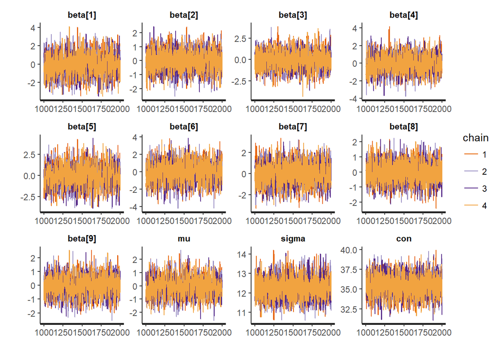

```r
traceplot(fit1, pars =names(fit1)[1:12])
```

##1.3 Note that nearly all the coefficients have shrunk to 0. This is because a gaussian prior is equivalent to a ridge regression which controls the effect size.It can be noted the covariates x1 and x3 are highly correlated and causes variation inflation. The inference in this case is highyl unstable. The gaussian prior stabilizes the variance bringing it closer to unity. The stan code is

```r
data {
  int<lower=0> N; // number of observations
  real y[N]; // responses
  matrix[N,9] x;

  real<lower =0> tau;
  }

parameters {
  vector[9] beta;
  real mu;

  real<lower=0> sigma;
  real con;
}
model {
  for(i in 1:N){
   y~normal(con + beta[1]*x[i,1]+ beta[2]*x[i,2]+ beta[3]*x[i,3] + beta[4]*x[i,4]+beta[5]*x[i,5] + beta[6]*x[i,6]+beta[7]*x[i,7] + beta[8]*x[i,8] + beta[9]*x[i,9],sigma);

  }
  for(j in 1:9)
  {
    beta[j]~normal(mu,tau);
  }

 target += -2*log(sigma);



}
```

## 1.4

```r
fit2 =stan(file = "q3.stan", data =list(N =length(y), y = dat$y, x = dat[,-1],
                                        iter = 2000, chains = 4, refresh = 0))
```

```r
load("fit2.RData")
print(fit2)
```

```
## Inference for Stan model: q3.
## 4 chains, each with iter=2000; warmup=1000; thin=1;
## post-warmup draws per chain=1000, total post-warmup draws=4000.
##
##            mean se_mean   sd    2.5%     25%     50%     75%   97.5% n_eff
## beta[1]    0.01    0.01 0.94   -1.88   -0.57   -0.01    0.59    1.86  4000
## beta[2]   -0.01    0.01 0.68   -1.34   -0.45    0.00    0.43    1.25  4000
## beta[3]    0.00    0.02 1.06   -2.10   -0.64    0.00    0.64    2.08  4000
## beta[4]    0.00    0.01 0.86   -1.71   -0.54    0.02    0.56    1.68  4000
## beta[5]   -0.01    0.01 0.94   -1.84   -0.60    0.00    0.58    1.90  4000
## beta[6]    0.01    0.01 0.92   -1.86   -0.56    0.01    0.60    1.86  4000
## beta[7]   -0.01    0.01 0.93   -1.93   -0.60    0.00    0.62    1.80  4000
## beta[8]    0.00    0.01 0.66   -1.31   -0.43   -0.01    0.42    1.32  4000
## beta[9]    0.01    0.01 0.65   -1.29   -0.41    0.01    0.44    1.31  4000
## sigma     12.24    0.01 0.54   11.25   11.87   12.21   12.59   13.36  4000
## con       35.50    0.02 1.31   32.87   34.61   35.49   36.35   38.11  4000
## lp__    -775.26    0.07 2.59 -781.15 -776.80 -774.90 -773.33 -771.28  1518
##         Rhat
## beta[1]    1
## beta[2]    1
## beta[3]    1
## beta[4]    1
## beta[5]    1
## beta[6]    1
## beta[7]    1
## beta[8]    1
## beta[9]    1
## sigma      1
## con        1
## lp__       1
##
## Samples were drawn using NUTS(diag_e) at Thu Mar 29 13:03:48 2018.
## For each parameter, n_eff is a crude measure of effective sample size,
## and Rhat is the potential scale reduction factor on split chains (at
## convergence, Rhat=1).
```

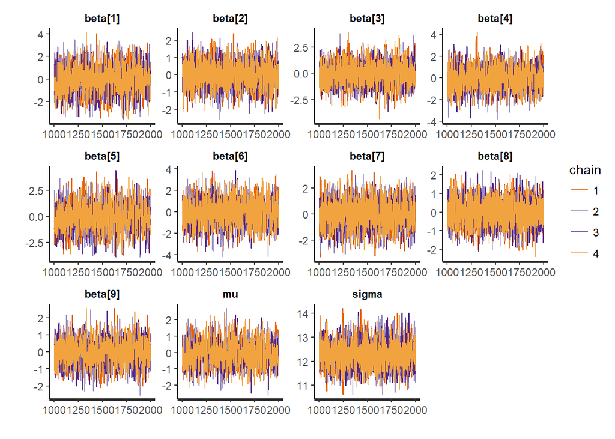

```r
traceplot(fit1, pars =names(fit1)[1:11])
```

The t distribution has a heavier tail than the gaussian and allows more exploration of the space. The estimates are again close to 0 but with a greater effective sample size. ##1.5 One could try models with different other prior specification. Infact instead of a gaussian prior one could use laplace to mimic lasso. ##2.1 Refer to Peter Hoff’s book for the distribution under zellner’s G prior. The results and code are given below.

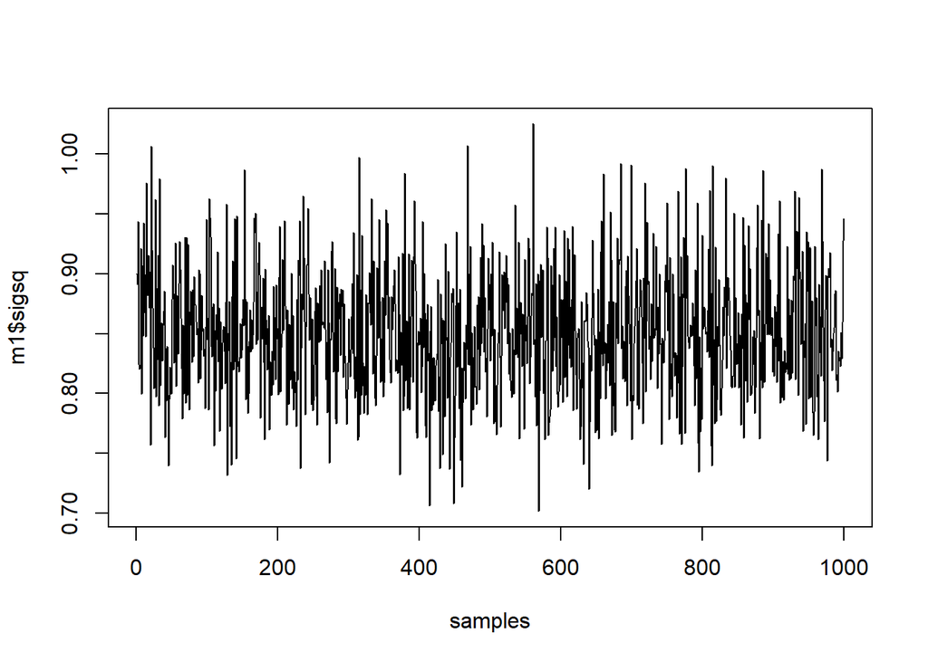

```r
library(MASS)
dat1 = as.data.frame(Pima.tr);dat2 = as.data.frame(Pima.te); data = rbind(dat1,dat2); data = data[-8]

pos = function(y,x,g,nu_0,sig_0,S)
{

  n = dim(x)[1]; p = dim(X)[2]
  Hg = (g/(g+1))*(x%*%solve(t(x)%*%x)%*%t(x))
  SSRg = t(y)%*%(diag(1,nrow = n) - Hg)%*%y
  sig = 1/rgamma(S,(nu_0+n)/2,(nu_0*sig_0 + SSRg)/2)
  Vb <-  g*solve(t(X)%*%X)/(g+1)
  Eb <- Vb%*%t(X)%*%y
  E <- matrix (rnorm(S*p , 0 , sqrt(sig)),S,p)
  beta <- t(t(E%*%chol(Vb))+c(Eb))
  return(list(beta = beta, sigsq = sig))

}
data = apply(data,2,f)
y = as.vector(data[,2]); X = as.matrix(data[,-2]);S = 1000
m1 = pos(y,X,532,2,1,S)
ts.plot(m1$sigsq,xlab = "samples")
```

```r
mean(m1$sigsq)
```

```
## [1] 0.8510828
```

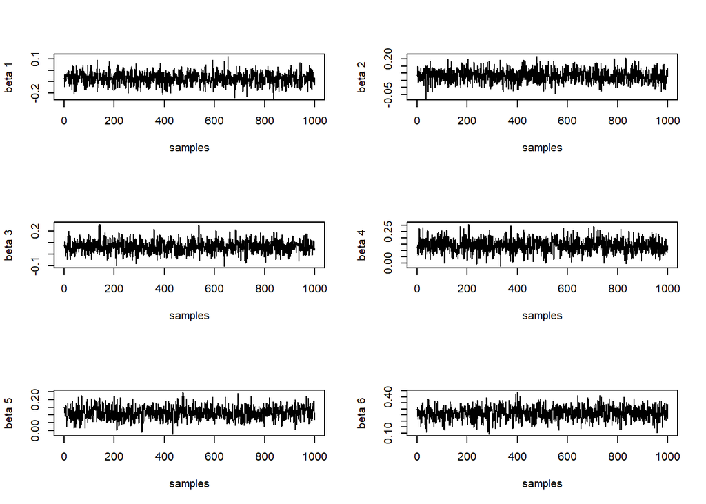

```r
par(mfrow = c(3,2))
for(i in 1:6)
{
  ts.plot(m1$beta[,i], xlab = "samples", ylab = paste("beta",i))
}
```

```r
colMeans(m1$beta)
```

```
##       npreg          bp        skin         bmi         ped         age
## -0.07173472  0.08094448  0.06658077  0.14053822  0.11573013  0.26573647
```

```r
std = apply(m1$beta,2,sd)
posin = apply(m1$beta,2,function(x)quantile(x,c(0.025,.975)))
```

## 2.2

Using bayesian model selection and averaging, we combine the gibbs code by Hoff for model averaging along with the code for posterior from g prior to get inference.

```r
lpy.X <- function( y ,X, g=length( y ),
                          nu_0=2, sig_0=1)
{
  n <- dim(X)[1] ; p <- dim(X)[2]
  if ( p==0) { Hg <- 0 ; }
  if ( p>0) { Hg <- (g /( g+1))*X%*%solve(t(X)%*%X)%*%t(X)}
  SSRg <-  t(y)%*%( diag(1,nrow=n )- Hg)%*%y
  ans = -.5*( n* log(pi)+p*log(1+g)+(nu_0+n)*log(nu_0* sig_0+SSRg)-
        nu_0*log(nu_0* sig_0)) +  lgamma (( nu_0+n ) / 2 ) - lgamma ( nu_0 / 2 )
  return(ans)
}
#####
##### starting values and MCMC setup
z <- rep ( 1 , dim(X)[2])
lpy.c <- lpy.X(y,X[ , z==1,drop=FALSE] )
S <- 10000
Z <- matrix (NA, S , dim(X)[2])
B = matrix (NA, S , dim(X)[2])
sigsq = rep(NA,S)
#####
##### Gibbs s ample r
for ( s in 1:S )
{
  for ( j in sample ( 1:dim(X)[2]))
  {
    zp <- z ; zp [j] <- 1-zp[j]
    lpy.p <- lpy.X( y ,X[, zp==1,drop=FALSE] )
    r <-  ( lpy.p - lpy.c )*( -1)^( zp[j]==0)
    z [ j ] <- rbinom ( 1 , 1 , 1/( 1+ exp(-r ) ) )
    if ( z [j]==zp [ j ] ) { lpy.c <- lpy.p}
  }
  Z [ s ,] <- z
  m = pos(y,X[,z==1],length(y),nu_0 = 2,sig_0 = 1,S = 1)
  B[s,] = m$beta; sigsq[s] = m$sigsq

}
```

The inference is given below.

```r
dat = read.csv("part2.csv",header = T);dat = dat[,-1]
Z = dat[,1:6]; Beta = dat[,7:12]; sigsq = dat[,13]
prob = colMeans(Z); nm = colnames(data); nm = nm[-2]; cbind(nm,prob)
```

```
##     nm      prob
## X.1 "npreg" "0.098"
## X.2 "bp"    "0.1791"
## X.3 "skin"  "0.0933"
## X.4 "bmi"   "0.9866"
## X.5 "ped"   "0.7112"
## X.6 "age"   "1"
```

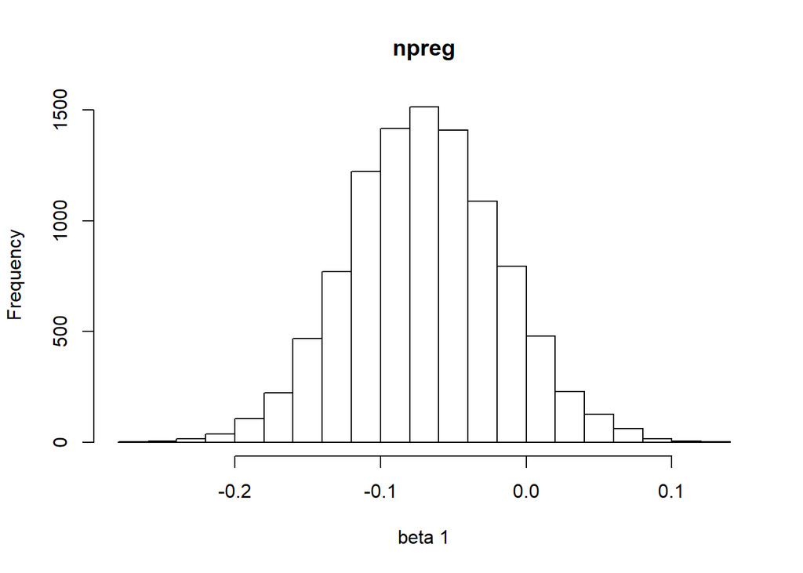

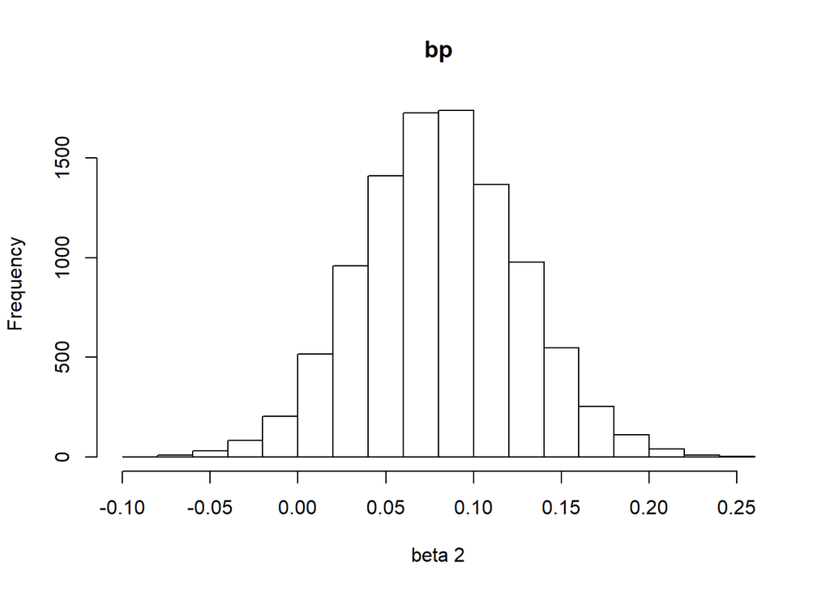

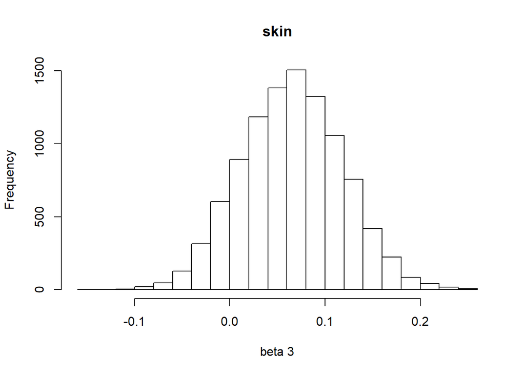

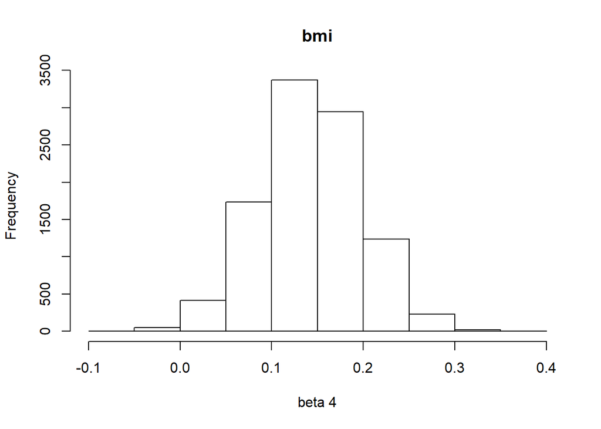

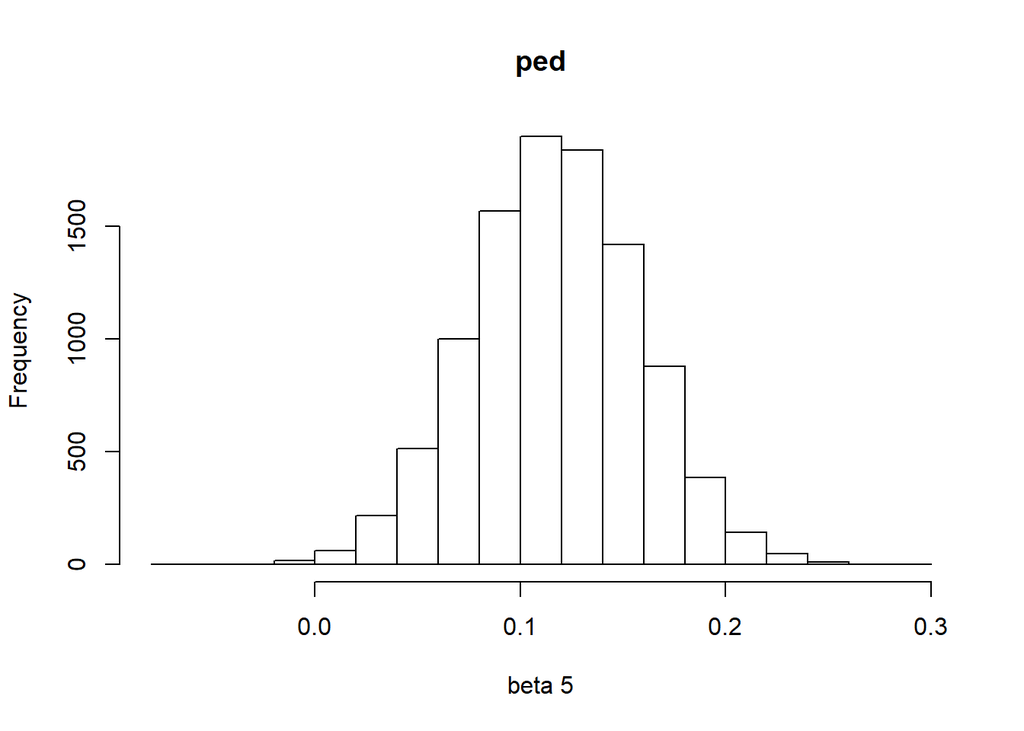

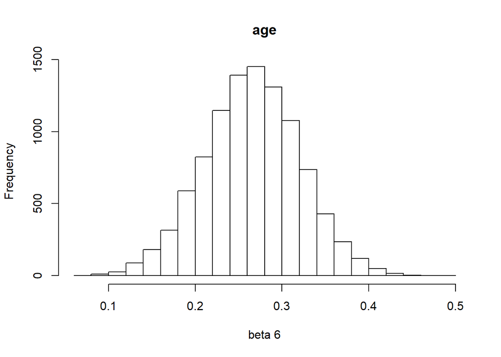

```r
for(i in 1:6)
{
  hist(Beta[,i], xlab = paste("beta",i),main = nm[i])
}
```

```r
posin2 = apply(Beta,2,function(x)quantile(x,c(0.025,.975)))
colnames(posin2) = nm
colnames(posin) = nm
posin ;posin2
```

```
##             npreg           bp        skin        bmi        ped       age
## 2.5%  -0.17908801 -0.001867802 -0.03437439 0.03150399 0.04087509 0.1542160
## 97.5%  0.03496003  0.170096760  0.17151983 0.24960672 0.19627319 0.3648066
```

```
##             npreg           bp        skin        bmi        ped       age
## 2.5%  -0.17151846 -0.005789482 -0.03466761 0.03433984 0.03773092 0.1549581
## 97.5%  0.03538579  0.171724770  0.16928104 0.24983386 0.19636866 0.3734474
```

The confidence intervals from the joint posterior are similar. The last three variables should be selected